# TITLE

# Plots

### Tuition vs Average Wage Index

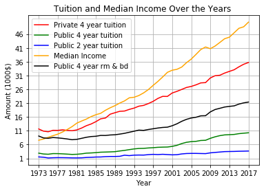

```python
#GRAPH 1

#plot Tuition vs Average Wage Index
plt.plot(masterTable.columns,masterTable.loc["pv_np_4fr_tuition"] / 1000, color = 'red',label = "Private 4 year tuition")
plt.plot(masterTable.columns,masterTable.loc["pb_4fr_tuition"] / 1000, color = 'green',label = "Public 4 year tuition")
plt.plot(masterTable.columns,masterTable.loc["pb_two_2yr_tuition"] / 1000, color = 'blue',label = "Public 2 year tuition")
plt.plot(masterTable.columns,masterTable.loc["average_wage_index"] / 1000,label = "Median Income", color = "orange")
plt.plot(masterTable.columns,masterTable.loc["pb_4fr_tuition_bd"] / 1000,label = "Public 4 year rm & bd", color = "black")
plt.grid()
plt.xlabel("Year")
plt.ylabel("Amount (1000$)")
plt.xticks(np.arange(min(masterTable.columns), max(masterTable.columns)+1, 4))
plt.yticks(np.arange(1, 51, step=5))
plt.legend(loc = 'best')
plt.title("Tuition and Median Income Over the Years ")
#plt.ylim(10500,36000)
plt.show()
```

### Ratio of Federal Loans to Average Wage Index vs. Time

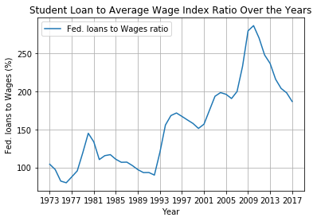

```python
#GRAPH 2

plt.plot(masterTable.columns,masterTable.loc["tot_fed_loans"] / masterTable.loc["average_wage_index"] * 100,\
         label = "Fed. loans to Wages ratio")
plt.xlabel("Year")
plt.ylabel("Fed. loans to Wages (%)")
plt.xticks(np.arange(min(masterTable.columns), max(masterTable.columns)+1, 4))
plt.grid()
plt.legend(loc = 'best')
plt.title("Student Loan to Average Wage Index Ratio Over the Years")
plt.show()
```

### Student Debt vs. Time

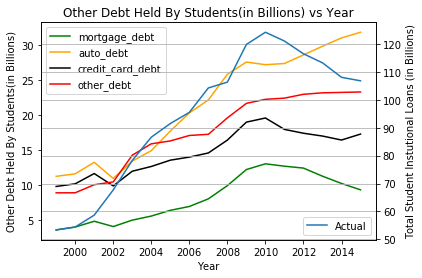

```python
#GRAPH3

x = df_fed_stu['year']
x2 =df_fed_stu['year']
y = df_fed_stu['mortgage_debt']
y1 = df_fed_stu['auto_debt']
y2 = df_fed_stu['credit_card_debt']
y3 = df_fed_stu['other_debt']
y4 = df_fed_stu['Actual']

fig, ax1 = plt.subplots()

ax1.plot(x, y, color='g')
ax1.plot(x, y1, color='orange')
ax1.plot(x, y2, color='black')
ax1.plot(x, y3, color='red')

ax2 = ax1.twinx()
ax2.plot(x2, y4)

plt.grid()

ax1.set_xlabel('Year')
ax1.set_ylabel('Other Debt Held By Students(in Billions)')
ax2.set_ylabel('Total Student Instutional Loans (in Billions)')
plt.title('Other Debt Held By Students(in Billions) vs Year')
ax1.legend(loc= 'best')
ax2.legend(loc = 'lower right')
plt.show()
```

### Enrollment, Tuition and Loans vs. Time

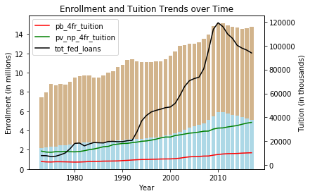

```python
#GRAPH 4

fig, ax1=plt.subplots()

y=final_merged_table["enrollment_public_millions"]
y1=final_merged_table["enrollment_private_millions"]
y2=final_merged_table["pb_4fr_tuition"]
y3=final_merged_table["pv_np_4fr_tuition"]
y4=final_merged_table["tot_fed_loans"]
x=final_merged_table["year"]

ax1.bar(x, y, color="tan")
ax1.bar(x, y1, color="lightblue")

ax2=ax1.twinx()
ax2.plot(x, y2, color="r")
ax2.plot(x, y3, color="green")
ax2.plot(x, y4, color="black")


ax1.set_xlabel("Year")
ax1.set_ylabel("Enrollment (in millions)")
ax2.set_ylabel("Tuition (in thousands)")

#ax1.legend(loc="upper left")
ax2.legend(loc="upper left")

plt.title ("Enrollment and Tuition Trends over Time")
plt.show()
```

### Breakdown of Student Aid

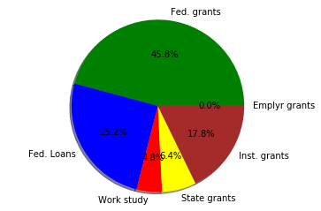

```python
#GRAPH 5

pieLabels = ["Fed. grants","Fed. Loans","Work study","State grants","Inst. grants","Emplyr grants"]
pieColors = ["green","blue","red","yellow","brown","pink"]
size1973 = [(masterTable.loc["tot_federal_grants",masterTable.columns[0]] /masterTable.loc["tot_std_aid_loans",masterTable.columns[0]]* 100)\
           ,(masterTable.loc["tot_fed_loans",masterTable.columns[0]] /masterTable.loc["tot_std_aid_loans",masterTable.columns[0]]* 100)\
           ,(masterTable.loc["fedral_work_study",masterTable.columns[0]] /masterTable.loc["tot_std_aid_loans",masterTable.columns[0]]* 100)\
           ,(masterTable.loc["state_grants",masterTable.columns[0]] /masterTable.loc["tot_std_aid_loans",masterTable.columns[0]]* 100)\
           ,(masterTable.loc["institutional_grants",masterTable.columns[0]] /masterTable.loc["tot_std_aid_loans",masterTable.columns[0]]* 100)\
           ,(masterTable.loc["private_employer_grants",masterTable.columns[0]] /masterTable.loc["tot_std_aid_loans",masterTable.columns[0]]* 100)\
           ]

plt.pie(size1973,labels = pieLabels, colors = pieColors,autopct = '%1.1f%%',shadow = True)
plt.axis("equal")
plt.show()
```

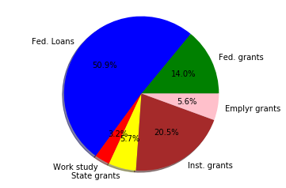

```python
size1995 = [(masterTable.loc["tot_federal_grants",masterTable.columns[22]] /masterTable.loc["tot_std_aid_loans",masterTable.columns[22]]* 100)\
           ,(masterTable.loc["tot_fed_loans",masterTable.columns[22]] /masterTable.loc["tot_std_aid_loans",masterTable.columns[22]]* 100)\
           ,(masterTable.loc["fedral_work_study",masterTable.columns[22]] /masterTable.loc["tot_std_aid_loans",masterTable.columns[0]]* 100)\
           ,(masterTable.loc["state_grants",masterTable.columns[22]] /masterTable.loc["tot_std_aid_loans",masterTable.columns[22]]* 100)\
           ,(masterTable.loc["institutional_grants",masterTable.columns[22]] /masterTable.loc["tot_std_aid_loans",masterTable.columns[22]]* 100)\
           ,(masterTable.loc["private_employer_grants",masterTable.columns[22]] /masterTable.loc["tot_std_aid_loans",masterTable.columns[22]]* 100)\
           ]

plt.pie(size1995,labels = pieLabels, colors = pieColors,autopct = '%1.1f%%',shadow = True)
plt.axis("equal")
plt.show()
```

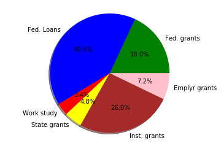

```python
size2017 = [(masterTable.loc["tot_federal_grants",masterTable.columns[44]] /masterTable.loc["tot_std_aid_loans",masterTable.columns[44]]* 100)\
           ,(masterTable.loc["tot_fed_loans",masterTable.columns[44]] /masterTable.loc["tot_std_aid_loans",masterTable.columns[44]]* 100)\
           ,(masterTable.loc["fedral_work_study",masterTable.columns[44]] /masterTable.loc["tot_std_aid_loans",masterTable.columns[0]]* 100)\
           ,(masterTable.loc["state_grants",masterTable.columns[44]] /masterTable.loc["tot_std_aid_loans",masterTable.columns[44]]* 100)\
           ,(masterTable.loc["institutional_grants",masterTable.columns[44]] /masterTable.loc["tot_std_aid_loans",masterTable.columns[44]]* 100)\
           ,(masterTable.loc["private_employer_grants",masterTable.columns[44]] /masterTable.loc["tot_std_aid_loans",masterTable.columns[44]]* 100)\
           ]

plt.pie(size2017,labels = pieLabels, colors = pieColors,autopct = '%1.1f%%',shadow = True)
plt.axis("equal")
plt.show()
```

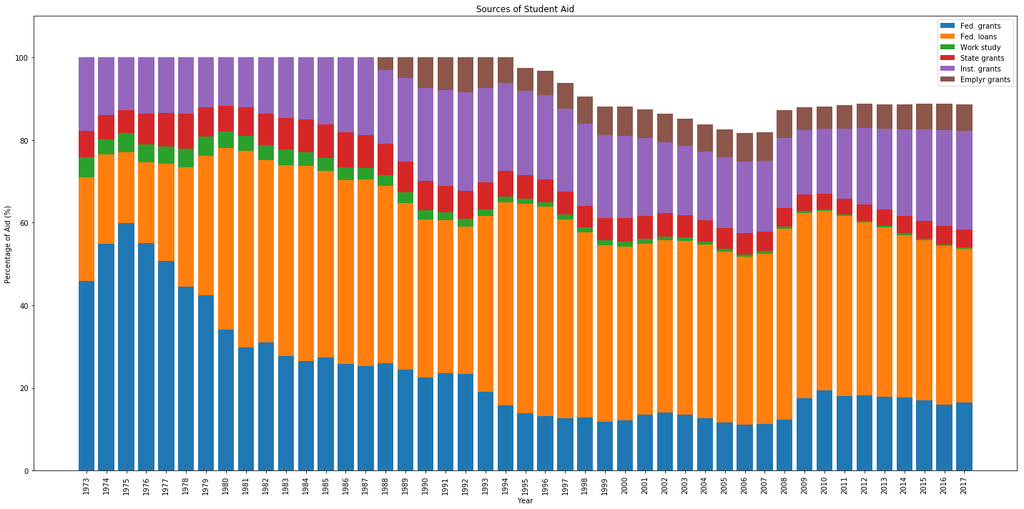

```python
plt.figure(figsize=(20,10))
dataSet1 = masterTable.loc["tot_federal_grants"] / masterTable.loc["tot_std_aid_loans"] *100
dataSet2 = masterTable.loc["tot_fed_loans"] / masterTable.loc["tot_std_aid_loans"] *100
dataSet3 = masterTable.loc["fedral_work_study"] / masterTable.loc["tot_std_aid_loans"] *100
dataSet4 = masterTable.loc["state_grants"] / masterTable.loc["tot_std_aid_loans"] *100
dataSet5 = masterTable.loc["institutional_grants"] / masterTable.loc["tot_std_aid_loans"] *100
dataSet6 = masterTable.loc["private_employer_grants"] / masterTable.loc["tot_std_aid_loans"] *100

p1 = plt.bar(masterTable.columns,dataSet1)
p2 = plt.bar(masterTable.columns,dataSet2, bottom = dataSet1 )
p3 = plt.bar(masterTable.columns,dataSet3, bottom = np.array(dataSet1)+np.array(dataSet2))
p4 = plt.bar(masterTable.columns,dataSet4, bottom = np.array(dataSet1)+np.array(dataSet2)+np.array(dataSet3))
p5 = plt.bar(masterTable.columns,dataSet5, bottom = np.array(dataSet1)+np.array(dataSet2)+np.array(dataSet3)+np.array(dataSet4))
p6 = plt.bar(masterTable.columns,dataSet6, bottom = np.array(dataSet1)+np.array(dataSet2)+np.array(dataSet3)+np.array(dataSet4)+np.array(dataSet5))
plt.title("Sources of Student Aid")
plt.ylabel("Percentage of Aid (%)")
plt.xlabel("Year")
plt.ylim(0,110)
plt.xticks(masterTable.columns,rotation="vertical")
plt.legend((p1[0],p2[0],p3[0],p4[0],p5[0],p6[0]),("Fed. grants","Fed. loans","Work study","State grants","Inst. grants","Emplyr grants"),loc = "best")
plt.tight_layout()
plt.show()
```

### Statistical Test

#### Polynomial Regression

```python
#get polynomial coefficients
x = masterTable.loc["pv_np_4fr_tuition"]
y = masterTable.loc["tot_fed_loans"]
g = x.astype(float)
j = y.astype(float)
(coeff1, coeff2, coeff3) = np.polyfit(g, j, 2, rcond=None, full=False, w=None, cov=False)

#define polynomial equation
fit = coeff1*(g**2) + coeff2*j + coeff3
```

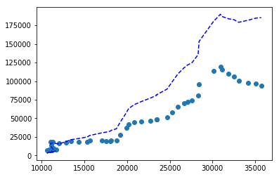

```python
#plot polynomial regression
fig, ax = plt.subplots()

ax.plot(g, j, linewidth=0, marker ='o')
ax.plot(g, fit, 'b--')

plt.show()
```

#### Linear Regression

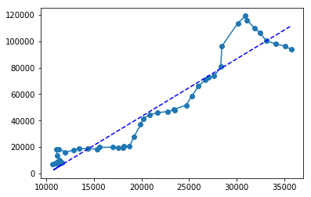

```python
#linear regression
(slope, intercept, _, _, _) = linregress(g,j)
fit = slope * g + intercept
fig, ax = plt.subplots()
ax.plot(g,j, marker = 'o')
ax.plot(g, fit, 'b--')
plt.show()
```

# Summary

### Student Loan debt to Average Wage Index Ratio Over the Years

• American Recovery and Reinvestment Act of 2009 had a big influence in 2009 after the great recession to incentivize higher education by boosting Pell Grants and Federal Loans.

o It was nicknamed the Recovery Act, was a stimulus package enacted by the 111th U.S. Congress and signed into law by President Barack Obama in February 2009. Developed in response to the Great Recession. Stimulus was focused on Immediate Relief for Families, Modernize Federal Infrastructure, Increase Alternative Energy Production, Expand Health Care, Education, Invest in Science Research and Technology, and helping small businesses.

### Enrollment and Tuition Trends for years (1973 – 2017)

Enrollment

[output not shown]

Tuition

[output not shown]

Student Loans

[output not shown]